# Estatística inferencial para a média no caso de grandes amostras

Mauro Campos

08 de julho de 2023

**Referências** para leitura deste material:

- P. Morettin & W. Bussab. Estatística Básica. 6a ed. São Paulo: Saraiva, 2010.
- M. Magalhães & AC. Lima. Noções de Probabilidade e Estatística Básica. 5a ed. São Paulo: EDUSP, 2002.
- M. Campos. Introdução ao R. Vitória, 2018. Disponível em: https://maurocmcampos.github.io/ec/html/intror.html.
- M. Campos. Funções do R para estatística descritiva. Vitória, 2023. Disponível em: https://maurocmcampos.github.io/ec/html/edR.html.

**Resumo**: Este material apresenta as funções do R para desenvolver procedimentos de estatística inferencial para a média populacional no caso de grandes amostras. Por procedimentos inferenciais pra média entendemos que são os procedimentos de **estimação** e **teste de hipóteses** para este parâmetro populacional. No caso de grandes amostras, estes procedimentos são fundamentados em dois teoremas limites da teoria das probabilidades, a saber: a lei dos grandes números e o teorema central do limite. Portanto, por terem tais fundamentos, discutiremos inicialmente os teoremas limites antes de discutir os procedimentos inferenciais.

# 1 Teoremas limites

## 1.1 Um pouco da linguagem da estatística inferencial

Estatística inferencial é fundamentada na teoria das probabilidades, mas por vezes possui uma linguagem própria. O objetivo aqui é fixar alguns termos dessa linguagem e estabelecer uma conexão direta entre estatística inferencial e teoria das probabilidades. Os termos que seguem possuem as seguintes explicações:

- **População**. Termo utilizado para se referir à distribuição de probabilidade de uma variável aleatória (va.a.) $y$ descrevendo um atributo de interesse que pode ser observado nos elementos de uma população real em um determinado estudo. Como estudamos no ínicio da nossa disciplina, os elementos dessa população real podem ser pessoas, animais, objetos, etc. Se $y$ é uma va.a., usaremos os símbolos $y\sim f(y)$ (ou $y\sim F(y)$) para informar que $y$ é uma va.a. descrita pela distribuição $f$ (ou $F$), onde $f$ é a função de probabilidade (se $y$ é discreta) ou a função densidade de probabilidade (se $y$ é contínua) e $F$ é a função de distribuição acumulada de $y$.
- **Média populacional**. Termo utilizado para se referir à média de uma população (ou distribuição de probabilidade). Se $y\sim f(y)$, então a média $\mu$ de $y$ é definida por $\mu=E(y)=\sum_{y}yf(y)$ (se $y$ é discreta) ou por $\mu=E(y)=\int yf(y)dy$ (se $y$ é contínua).
- **Variância populacional**. Termo utilizado para se referir à variância de uma população. Se $y\sim f(y)$, então a variância $\sigma^{2}$ de $y$ é definida por $\sigma^{2}=Var(y)=E[(y-E(y))^{2}]$.
- **Desvio-padrão populacional**. Termo utilizado para se referir ao desvio-padrão de uma população. Se $y\sim f(y)$, então o desvio-padrão $\sigma$ de $y$ é definido por $\sigma=\sqrt{Var(y)}=\sqrt{\sigma^{2}}$.
- **Amostra aleatória simples**. Uma amostra aleatória simples (a.a.s.) de tamanho $n$ de uma va.a. $y\sim f(y)$ é o termo utilizado para se referir a um conjunto de $n$ va.a.’s independentes $y_{1},y_{2},\ldots,y_{n}$, cada uma com a mesma distribuição de $y$. Ou seja, na prática, uma a.a.s. de tamanho $n$ de uma va.a. $y$ representa um conjunto de $n$ observações independentes, cada uma retirada da população de $y$.
- **Estatísticas amostrais**. No ínicio da nossa disciplina estudamos alguma estatísticas amostrais. Vimos que uma estatística é uma função dos valores amostrais que descreve uma certa característica da amostra observada. Por exemplo, se $y_{1},y_{2},\ldots,y_{n}$ representa uma a.a.s. de uma variável $y$, então a **média amostral**, definida por $\bar{y}=(1/n)\sum_{i}y_{i}$, é uma estatística que pode ser usada como uma medida de tendência central dos dados, ou seja, um ponto central em torno do qual os dados amostrais estão distribuídos. Vimos também que a média amostral é uma estatística que funciona como estimador com boa propriedades para a média populacional $\mu$ (onde $-\infty<\mu<+\infty$), que em geral é um parâmetro desconhecido de uma certa população de interesse. Outros exemplos de estatísticas amostrais são:
  - **Proporção amostral**. Se $y_{1},y_{2},\ldots,y_{n}$ representa uma a.a.s. de uma variável $y$ dicotômica ($y\in\{0,1\}$), então a proporção amostral, definida por $\hat{p}=(1/n)\sum_{i}y_{i}$, que funciona como estimador com boa propriedades para a proporção populacional $p$ (onde $0<p<1$), que em geral é um parâmetro desconhecido de uma certa população de interesse.
  - **Variância amostral**. se $y_{1},y_{2},\ldots,y_{n}$ representa uma a.a.s. de uma variável $y$, então a variância amostral, definida por $s^{2}=(1/(n-1))\sum_{i}(y_{i}-\bar{y})^{2}$, é uma estatística que pode ser usada como uma medida de variabilidade dos dados amostrais em torno da média amostral. Além disso, vimos que a variância amostral é uma estatística que funciona como estimador com boa propriedades para a variância populacional $\sigma^{2}$ (onde $0<\sigma^{2}<+\infty$), que em geral é um parâmetro desconhecido de uma certa população de interesse.
  - **Desvio padrão amostral**. se $y_{1},y_{2},\ldots,y_{n}$ representa uma a.a.s. de uma variável $y$, então o desvio-padrão amostral, definido por $s=\sqrt{s^{2}}$, é uma estatística que pode ser usada como uma medida de variabilidade dos dados amostrais em torno da média amostral. Vimos também que o desvio-padrão amostral é uma estatística que funciona como estimador com boa propriedades para o desvio-padrão populacional $\sigma$ (onde $0<\sigma<+\infty$), que em geral é um parâmetro desconhecido de uma certa população.

## 1.2 A lei dos grandes números

**Resultado** (LGN - Lei dos grandes números). Seja $y_{1},y_{2},\ldots,y_{n}$ uma a.a.s. de uma va.a. $y$ com média $\mu$ finita e variância $\sigma^{2}$ finita e seja
$$\bar{y}=\frac{1}{n}\sum_{i=1}^{n}y_{i}$$
a média amostral. Então, para qualquer $\varepsilon>0$,
$$\lim_{n\rightarrow\infty}\Pr\left(|\bar{y}-\mu|>\varepsilon\right)=0.$$

Em palavras, a LGN afirma que com alta probabilidade a média amostral $\bar{y}$ está muito próxima da média populacional $\mu$ se o tamanho amostral $n$ é suficientemente grande. Formalmente, a convergência em questão é chamada de **convergência em probabilidade** e para denotá-la usamos os seguintes símbolos:
$$\bar{y}=\frac{1}{n}\sum_{i=1}^{n}y_{i}\stackrel{\Pr}{\rightarrow}\mu\hspace{1cm}
\mbox{quando $n\rightarrow\infty$}.$$

**Simulação**. A seguinte simulação exemplifica a LGN usando amostras da distribuição normal $\mbox{N}(2,1)$. Note a convergência da média amostral para a média populacional para todas as amostras simuladas.

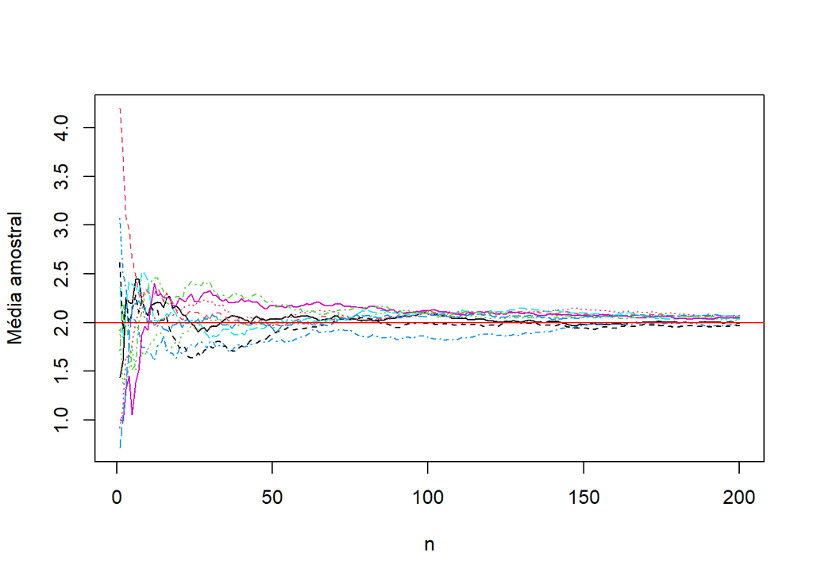

```r
set.seed(123)
n <- 200
mat.y <- matrix(NA,n,10)
for(j in 1:10){
  y <- rnorm(n,mean=2,sd=1)
  for(i in 1:n){mat.y[i,j] <- mean(y[1:i])}
}
matplot(1:n,mat.y,type="l",xlab="n",ylab="Média amostral")
abline(h=2,col="red")
```

```r
dev.off()
## null device
##           1
```

A LGN é um resultado geral que vale para qualquer população com média finita. Entretanto, um caso particular importante é a LGN de Bernoulli, quando a população em questão é a distribuição de Bernoulli com parâmetro $p$ (ou seja, $\mbox{Be}(p)$, onde $0<p<1$). Lembre-se que se $y\sim\mbox{Be}(p)$, então $\mu=E(y)=p$ e $\sigma^{2}=Var(y)=p(1-p)$.

**Resultado** (LGN de Bernoulli). Seja $y_{1},y_{2},\ldots,y_{n}$ uma a.a.s. de uma va.a. $y\sim\mbox{Be}(p)$ e seja
$$\hat{p}=\frac{1}{n}\sum_{i=1}^{n}y_{i}$$
a proporção amostral. Então, $\hat{p}\stackrel{\Pr}{\rightarrow}p$ quando $n\rightarrow\infty$. Ou seja, com alta probabilidade a proporção amostral $\hat{p}$ está muito próxima da proporção populacional $p$ se o tamanho amostral $n$ é suficientemente grande.

**Simulação**. A seguinte simulação exemplifica a LGN de Bernoulli usando amostras da distribuição de Bernoulli $\mbox{Be}(0.6)$. Note a convergência da proporção amostral para a proporção populacional para todas as amostras simuladas.

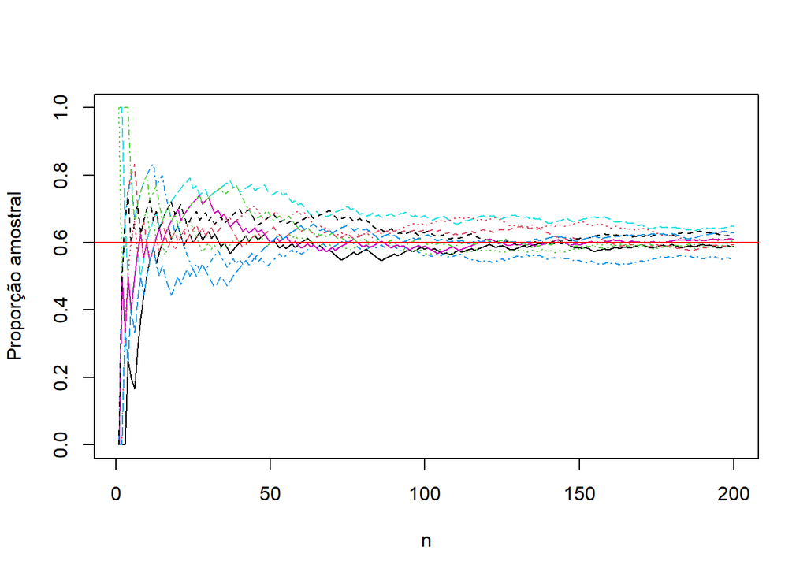

```r
set.seed(312)
n <- 200
mat.y <- matrix(NA,n,10)
for(j in 1:10){
  y <- rbinom(n,size=1,prob=0.6)
  for(i in 1:n){mat.y[i,j] <- mean(y[1:i])}
}
matplot(1:n,mat.y,type="l",xlab="n",ylab="Proporção amostral")
abline(h=0.6,col="red")
```

```r
dev.off()
## null device
##           1
```

## 1.3 O teorema central do limite

**Resultado** (TCL - Teorema central do limite). Seja $y_{1},y_{2},\ldots,y_{n}$ uma a.a.s. de uma va.a. $y$ com média $\mu$ finita e variância $\sigma^{2}$ finita e seja
$$z=\frac{\bar{y}-\mu}{\sigma/\sqrt{n}}$$
a média amostral padronizada. Então, a distribuição de $z$ é bem aproximada pela normal padrão se o tamanho amostral $n$ é suficientemente grande. Formalmente, a convergência em questão é chamada de **convergência em distribuição** e para denotá-la usamos os seguintes símbolos:
$$z=\frac{\bar{y}-\mu}{\sigma/\sqrt{n}}\stackrel{a}{\sim}\mbox{N}(0,1).$$
É importante ressaltar que este resultado equivale dizer que a distribuição da média amostral $\bar{y}$ é bem aproximada por uma normal com média $\mu$ e variância $\sigma^{2}/n$ se o tamanho amostral $n$ é suficientemente grande. Em símbolos:
$$\bar{y}\stackrel{a}{\sim}\mbox{N}\left(\mu,\frac{\sigma^{2}}{n}\right).$$

**Simulação**. A seguinte simulação exemplifica o TCL usando amostras da distribuição uniforme no intervalo $[0,1]$. Esta é uma distribuição contínua cuja função densidade de probabilidade é dada por $f(y)=1$ se $0\leq y\leq 1$ e $f(y)=0$ caso contrário. A média e a variância da distribuição uniforme no intervalo $[0,1]$ são $1/2$ e $1/12$, respectivamente. Note que a forma do histograma densidade para a média amostral padronizada concorda muito bem com a forma da função densidade de probabilidade da normal padrão, evidenciando assim o resultado do TCL que afirma que a distribuição da média amostral padronizada é bem aproximada pela distribuição normal padrão quando o tamanho amostral $n$ é suficientemente grande.

```r
set.seed(321)
M=1000;n=256
mu <- 1/2;sigma <- sqrt(1/12)
z <- rep(NA,M)
for(i in 1:M){
  amostra <- runif(n,0,1)
  z[i] <- sqrt(n)*(mean(amostra)-mu)/sigma
}
summary(z)
```

```
##      Min.   1st Qu.    Median      Mean   3rd Qu.      Max.
## -2.951602 -0.693122  0.002837  0.020414  0.681200  3.598610
```

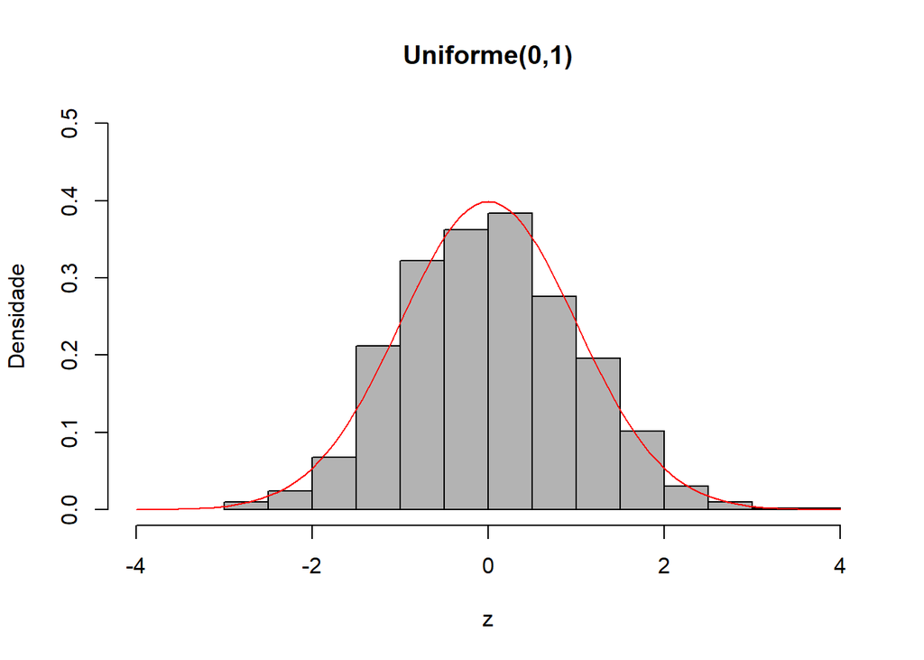

```r
hist(z,freq=FALSE,col="gray70",main="Uniforme(0,1)",xlim=c(-4,4),ylim=c(0,0.5),ylab="Densidade")
curve(dnorm(x,mean=0,sd=1),-4,4,add=TRUE,col="red")
```

```r
dev.off()
## null device
##           1
```

O TCL é um resultado geral que vale para qualquer população com média finita e variância finita. Entretanto, um caso particular importante é o TCL de De Moivre-Laplace, quando a população em questão é a distribuição de Bernoulli com parâmetro $p$.

**Resultado** (TCL de De Moivre-Laplace). Seja $y_{1},y_{2},\ldots,y_{n}$ uma a.a.s. de uma va.a. $y\sim\mbox{Be}(p)$ e seja
$$z=\frac{\hat{p}-p}{\sqrt{p(1-p)/n}}$$
a proporção amostral padronizada. Então, a distribuição de $z$ é bem aproximada pela normal padrão se o tamanho amostral $n$ é suficientemente grande. Em símbolos:
$$z=\frac{\hat{p}-p}{\sqrt{p(1-p)/n}}\stackrel{a}{\sim}\mbox{N}(0,1).$$
Novamente, é importante ressaltar que este resultado equivale dizer que a distribuição da proporção amostral $\hat{p}$ é bem aproximada por uma normal com média $p$ e variância $p(1-p)/n$ se o tamanho amostral $n$ é suficientemente grande. Em símbolos:
$$\hat{p}\stackrel{a}{\sim}\mbox{N}\left(p,\frac{p(1-p)}{n}\right).$$

**Simulação**. A seguinte simulação exemplifica o TCL de De Moivre-Laplace usando amostras da distribuição de Bernoulli $\mbox{Be}(0.6)$. Note que a forma do histograma densidade para a proporção amostral padronizada concorda muito bem com a forma da função densidade de probabilidade da normal padrão, evidenciando assim o resultado do TCL que afirma que a distribuição da proporção amostral padronizada é bem aproximada pela distribuição normal padrão quando o tamanho amostral $n$ é suficientemente grande.

```r
set.seed(213)
M=1000;n=256;p=0.6
mu <- p;sigma <- sqrt(p*(1-p))
z <- rep(NA,M)
for(i in 1:M){
  amostra <- rbinom(n,size=1,prob=0.6)
  z[i] <- sqrt(n)*(mean(amostra)-mu)/sigma
}
summary(z)
```

```
##      Min.   1st Qu.    Median      Mean   3rd Qu.      Max.
## -3.138409 -0.586857 -0.076547  0.003572  0.688919  2.985316
```

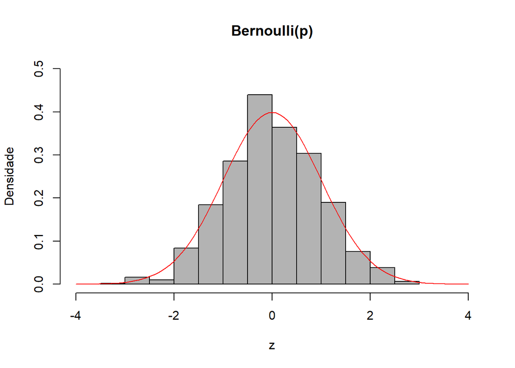

```r
hist(z,freq=FALSE,col="gray70",main="Bernoulli(p)",xlim=c(-4,4),ylim=c(0,0.5),ylab="Densidade")
curve(dnorm(x,mean=0,sd=1),-4,4,add=TRUE,col="red")
```

```r
dev.off()
## null device
##           1
```

## 1.4 Aproximação normal para a binomial

Concluindo essa primeira seção, vamos discutir uma aplicação do TCL de De Moivre-Laplace conhecida como **aproximação normal para a binomial**. Este resultado está discutido no nosso livro-texto (veja Morettin & Bussab (2010, Cap. 7)). Para entender esse resultado, basta observar que:
$$z=z\cdot\frac{n}{n}=\frac{\hat{p}-p}{\sqrt{p(1-p)/n}}\cdot\frac{n}{n}=
\frac{s-np}{\sqrt{np(1-p)}}\stackrel{a}{\sim}\mbox{N}(0,1)$$
onde $s=y_{1}+\cdots y_{n}\sim\mbox{Bin}(n,p)$.

**Resultado** (Aproximação normal para a binomial). Se $x\sim\mbox{Bin}(n,p)$, então para $a$ e $b$ inteiros não-negativos tais que $a<b$, a seguinte aproximação vale:
$$\Pr(a<x\leq b)\approx\Pr\left(
\frac{a-np}{\sqrt{np(1-p)}}<Z\leq\frac{b-np}{\sqrt{np(1-p)}}
\right)$$
onde $Z\sim\mbox{N}(0,1)$. A seguinte correção de continuidade melhora a aproximação
$$\Pr(a<x\leq b)\approx\Pr\left(
\frac{a+0.5-np}{\sqrt{np(1-p)}}<Z\leq\frac{b+0.5-np}{\sqrt{np(1-p)}}
\right).$$

**Problema**. Este exemplo está discutido em Morettin & Bussab (2010,Cap. 7). Se $x\sim\mbox{Bin}(10,1/2)$, calcule $\Pr(3<x\leq 6)$ exatamente. Obtenha também uma aproximação normal para essa probabilidade binomial com e sem correção de continuidade.

```r
n=10;p=1/2
#
# Resultado exato
#
sum(dbinom(4:6,size=n,prob=p))
```

```
## [1] 0.65625
```

```r
pbinom(6,size=n,prob=p)-pbinom(3,size=n,prob=p)
```

```
## [1] 0.65625
```

```r
#
# Resultado via aproximacao normal sem correcao de continuidade
#
pnorm(6,mean=n*p,sd=sqrt(n*p*(1-p)))-pnorm(3,mean=n*p,sd=sqrt(n*p*(1-p)))
```

```
## [1] 0.6335038
```

```r
#
# Resultado via aproximacao normal com correcao de continuidade
#
pnorm(6.5,mean=n*p,sd=sqrt(n*p*(1-p)))-pnorm(3.5,mean=n*p,sd=sqrt(n*p*(1-p)))
```

```
## [1] 0.6572183
```

# 2 Inferência para a média de uma população qualquer: grandes amostras

## 2.1 Estimação pontual da média

Seja $y_{1},y_{2},\ldots,y_{n}$ uma a.a.s. de uma va.a. $y\sim f(y)$ com média $\mu$ finita e variância $\sigma^{2}$ finita. Assuma que $\mu$ e $\sigma^{2}$ são parâmetros populacionais desconhecidos. Usaremos a média amostral $\bar{y}$ como um estimador pontual para $\mu$.

**Resultado**. Os seguintes resultados são válidos:

1. $\bar{y}\stackrel{\Pr}{\rightarrow}\mu$ quando $n\rightarrow\infty$.
2. $\bar{y}\stackrel{a}{\sim}\mbox{N}\left(\mu,\frac{\sigma^{2}}{n}\right)$ para $n$ grande.
- 1 garante que a LGN vale, ou seja, a média amostral converge em probabilidade para a média populacional. Isso significa que com alta probabilidade a média amostral está próxima da média populacional.
- 2 garante que o TCL vale, ou seja, que a distribuição da média amostral é bem aproximada por uma normal com média $\mu$ e variância $\sigma^{2}/n$ se o tamanho amostral $n$ é suficientemente grande.

**Resumo**. A média amostral é um estimador com boas propriedades para estimar a média de uma população.

**Problema**. O gerente de um restaurante está interessado na distribuição do tempo de entrega de pedidos realizados pelo aplicativo do restaurante. Para tal estudo, uma a.a.s. de 32 tempos de entrega (medidos em minutos) foram registrados (veja os dados no script R abaixo). Apresente uma estimativa pontual para o tempo médio de entrega de pedidos.

```r
dados <- c(4.24,9.94,11.31,11.84,13.89,19.97,21.18,22.15,
           22.44,24.69,25.20,25.36,25.62,26.96,27.25,27.42,
           29.98,32.54,32.98,34.88,35.34,35.44,35.57,36.29,
           37.03,38.13,41.88,44.16,48.89,49.78,51.63,52.27)
summary(dados)
```

```
##    Min. 1st Qu.  Median    Mean 3rd Qu.    Max.
##    4.24   22.37   28.70   29.88   36.48   52.27
```

```r
var(dados)
```

```
## [1] 153.3435
```

```r
sd(dados)
```

```
## [1] 12.38319
```

```r
media.amostral <- mean(dados)
media.amostral
```

```
## [1] 29.88281
```

Uma análise descritiva revela que o tempo médio amostral de entrega de pedidos é 29.88 minutos. Este valor pode ser usado como uma estimativa pontual para o verdadeiro tempo médio populacional de entrega de pedidos, que neste caso é um parâmetro desconhecido que só saberíamos seu verdadeiro valor se soubéssemos a distribuição exata da variável tempo de entrega de pedidos realizados pelo aplicativo do restaurante. Uma visualização dos dados revela que uma distribuição normal centrada no tempo médio amostral se ajusta bem aos dados observados.

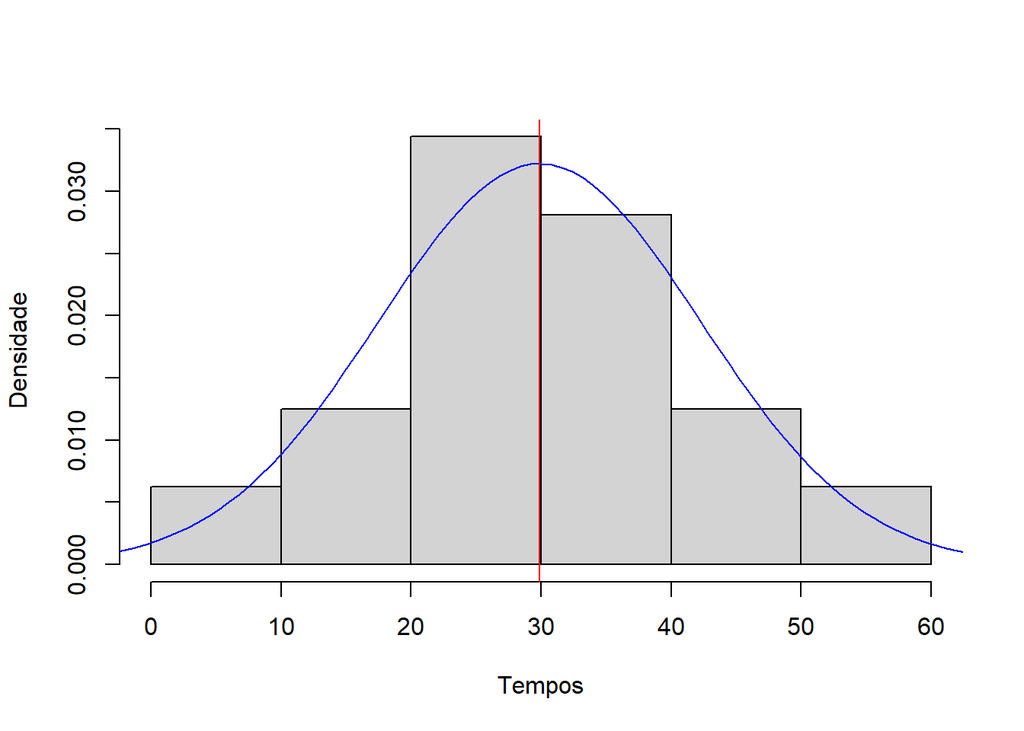

```r
hist(dados,freq=FALSE,xlab="Tempos",ylab="Densidade",main="")
curve(dnorm(x,mean=mean(dados),sd=sd(dados)),-10,70,col="blue",add=TRUE)
abline(v=mean(dados),col="red")
```

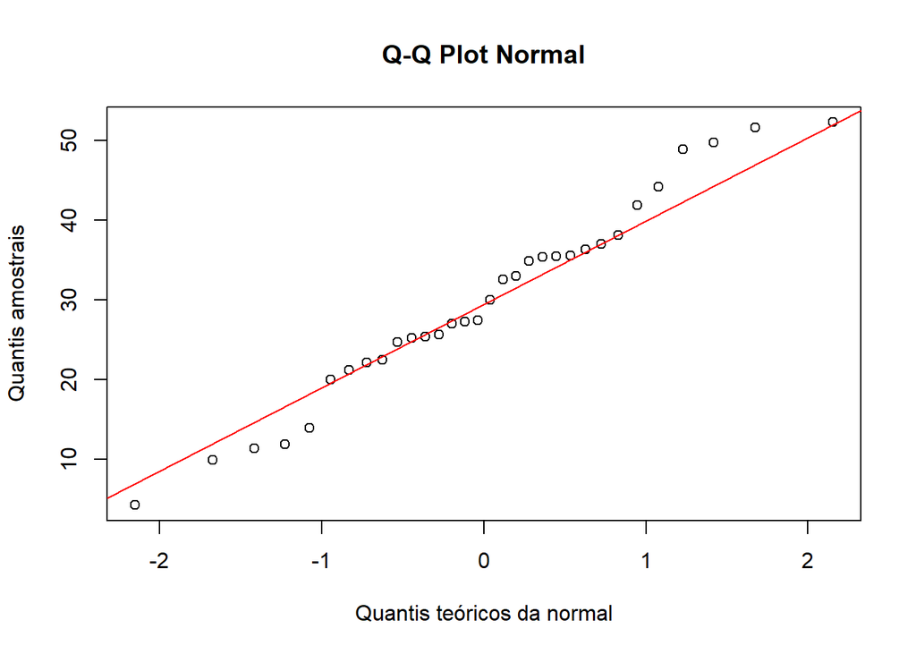

```r
qqnorm(dados,xlab="Quantis teóricos da normal",ylab="Quantis amostrais",main="Q-Q Plot Normal")
qqline(dados,col="red")
```

```r
dev.off()
## null device
##           1
```

## 2.2 Estimação intervalar da média

Seja $y_{1},y_{2},\ldots,y_{n}$ uma a.a.s. de uma va.a. $y\sim f(y)$ com média $\mu$ finita e variância $\sigma^{2}$ finita. A média amostral $\bar{y}$ proporciona estimativas pontuais para $\mu$. Estimativas intervalares para $\mu$ podem ser proporcionadas pelas seguintes equações:
$$IC(\mu;\gamma=1-\alpha)\approx\left[\bar{y}\pm
z_{\alpha/2}\cdot\frac{\sigma}{\sqrt{n}}\right]
\hspace{0.5cm}\mbox{se $\sigma$ conhecido}$$
ou
$$IC(\mu;\gamma=1-\alpha)\approx\left[\bar{y}\pm
z_{\alpha/2}\cdot\frac{s}{\sqrt{n}}\right]
\hspace{0.5cm}\mbox{se $\sigma$ desconhecido}.$$
$IC(\mu;\gamma=1-\alpha)$ proporciona um intervalo com aproximadamente $100\gamma\%$ de confiança de conter o verdadeiro valor de $\mu$. Acima $\bar{y}$ é a média amostral, $s$ é o desvio-padrão amostral e $z_{\alpha/2}$ é um quantil na distribuição normal padrão tal que $\Pr(Z>z_{\alpha/2})=\alpha/2$. No R, este quantil pode ser calculado automaticamente usando a função `qnorm()`. Veja a seguir, um exemplo quando $\alpha=5\%$.

```r
z <- qnorm(0.025,mean=0,sd=1,lower.tail=FALSE);z
```

```
## [1] 1.959964
```

```r
qnorm(0.975,mean=0,sd=1) # De forma equivalente
```

```
## [1] 1.959964
```

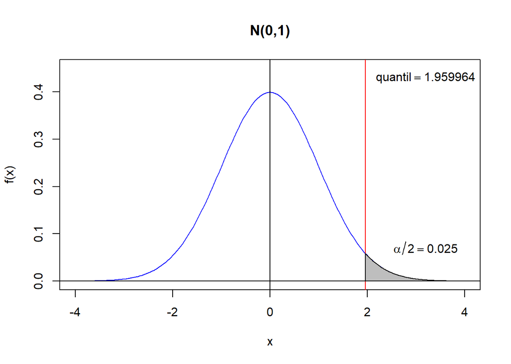

```r
x <- seq(-4,4,l=200);f <- dnorm(x,mean=0,sd=1)
plot(x,f,type = "l",col="blue",xlab="x",ylab="f(x)",ylim=c(0,0.45),main="N(0,1)")
abline(v=0,h=0);abline(v=z,col="red")
x1 <- seq(z,4,l=200);y1 <- dnorm(x1,mean=0,sd=1)
polygon(rbind(cbind(rev(x1),0),cbind(x1,y1)),col="gray")
text(3.2,0.43,expression(quantil==1.959964))
text(3.2,0.07,expression(alpha/2==0.025))
```

```r
dev.off()
## null device
##           1
```

**Resumo**. Se o tamanho amostral $n$ for suficientemente grande, então $IC(\mu;\gamma=1-\alpha)$ proporciona um intervalo com aproximadamente $100\gamma\%$ de confiança de conter o verdadeiro valor de $\mu$.

**Problema**. Considere os dados e a mesma situação do problema anterior. Proporcione uma estimativa intervalar para o tempo médio de entrega de pedidos realizados pelo aplicativo do restaurante com aproximadamente 95% de confiança de conter o verdadeiro valor desse tempo médio. Vale ressaltar mais uma vez que esse tempo médio é um parâmetro populacional desconhecido que só saberíamos seu verdadeiro valor se soubéssemos a distribuição exata da variável tempo de entrega de pedidos realizados pelo aplicativo do restaurante.

```r
dados <- c(4.24,9.94,11.31,11.84,13.89,19.97,21.18,22.15,
           22.44,24.69,25.20,25.36,25.62,26.96,27.25,27.42,
           29.98,32.54,32.98,34.88,35.34,35.44,35.57,36.29,
           37.03,38.13,41.88,44.16,48.89,49.78,51.63,52.27)
summary(dados)
```

```
##    Min. 1st Qu.  Median    Mean 3rd Qu.    Max.
##    4.24   22.37   28.70   29.88   36.48   52.27
```

```r
var(dados)
```

```
## [1] 153.3435
```

```r
sd(dados)
```

```
## [1] 12.38319
```

```r
length(dados)
```

```
## [1] 32
```

```r
z <- qnorm(0.025,mean=0,sd=1,lower.tail=FALSE);z
```

```
## [1] 1.959964
```

```r
ic.95 <- c(mean(dados)-z*sd(dados)/sqrt(length(dados)),
           mean(dados)+z*sd(dados)/sqrt(length(dados)))
ic.95
```

```
## [1] 25.59233 34.17329
```

Um intervalo com aproximadamente 95% confiança de conter o verdadeiro tempo médio populacional de entrega de pedidos é dado por $\mbox{IC}(\mu;0.95)\approx(25.59,34.17)$ minutos. Este resultado pode ser obtido automaticamente usando a função `z.test()` do pacote `TeachingDemos`. Este pacote não é nativo do R, sendo assim, ele precisa ser instalado e carregado para que suas funções funcionem adequadamente.

```r
library(TeachingDemos) # carrega do pacote previamente instalado
dados
```

```
##  [1]  4.24  9.94 11.31 11.84 13.89 19.97 21.18 22.15 22.44 24.69 25.20 25.36
## [13] 25.62 26.96 27.25 27.42 29.98 32.54 32.98 34.88 35.34 35.44 35.57 36.29
## [25] 37.03 38.13 41.88 44.16 48.89 49.78 51.63 52.27
```

```r
out <- z.test(x=dados,mu=mean(dados),stdev=sd(dados),alt="two.sided",n=length(dados),conf.level=0.95)
names(out)
```

```
## [1] "statistic"   "parameter"   "p.value"     "conf.int"    "estimate"
## [6] "null.value"  "alternative" "method"      "data.name"
```

```r
out$estimate
## mean of dados
##      29.88281
as.vector(out$conf.int)
```

```
## [1] 25.59233 34.17329
```

Alternativamente, o pacote `BSDA` (que também não é nativo do R) pode ser usado para se obter automaticamente o mesmo intervalo de confiança.

```r
dados
```

```
##  [1]  4.24  9.94 11.31 11.84 13.89 19.97 21.18 22.15 22.44 24.69 25.20 25.36
## [13] 25.62 26.96 27.25 27.42 29.98 32.54 32.98 34.88 35.34 35.44 35.57 36.29
## [25] 37.03 38.13 41.88 44.16 48.89 49.78 51.63 52.27
```

```r
BSDA::z.test(x=dados,alternative="two.sided",mu=mean(dados),sigma.x=sd(dados),conf.level=0.95) -> out
names(out)
```

```
## [1] "statistic"   "p.value"     "conf.int"    "estimate"    "null.value"
## [6] "alternative" "method"      "data.name"
```

```r
out$estimate
## mean of x
##  29.88281
as.vector(out$conf.int)
```

```
## [1] 25.59233 34.17329
```

## 2.3 Teste de hipóteses para a média

Seja $y_{1},y_{2},\ldots,y_{n}$ uma a.a.s. de uma va.a. $y\sim f(y)$ com média $\mu$ finita e variância $\sigma^{2}$ finita. Aqui, estamos interessados em usar a média amostral padronizada
$$z=\frac{\bar{y}-\mu_{0}}{s/\sqrt{n}}
\hspace{0.5cm}\mbox{ou}\hspace{0.5cm}
z=\frac{\bar{y}-\mu_{0}}{\sigma/\sqrt{n}}$$
como uma estatística para testar uma suposição (ou hipótese) quanto ao valor de $\mu$ ser igual a um valor $\mu_{0}$ fixado. Antes de discutir concretamente como realizar este teste, necessitamos formalizar alguns conceitos prévios.

### 2.3.1 Hipótese estatística e teste de hipóteses

Uma **hipótese estatística** relativa à média populacional é uma suposição quanto ao seu valor que será verificada por um teste de hipóteses. Um **teste de hipóteses** é uma regra de decisão desenvolvida para rejeitar ou não-rejeitar (aceitar) uma hipótese estatística com base em dados observados. Num teste de hipóteses, $H_{0}$ denota uma hipótese chamada de **hipótese nula**. A hipótese nula é testada contra uma hipótese chamada de **hipótese alternativa**, geralmente denotada por $H_{1}$ ou $H_{a}$. Em geral, $H_{1}$ representa uma suposição que o pesquisador deseja comprovar (ou não) empiricamente e $H_{0}$ representa uma hipótese conservadora formulada com a expectativa de ser rejeitada, caso exista nos dados observados, evidências experimentais contra $H_{0}$.

### 2.3.2 Testes bilaterais e unilaterais

Estamos interessados especificamente em testes de hipóteses para a média populacional. Tais testes podem ser definidos ou enunciados como um dos seguintes tipos:

- **Teste bilateral**: $H_{0}:\mu=\mu_{0}$ versus $H_{1}:\mu\not=\mu_{0}$.
- **Teste unilateral à direita**: $H_{0}:\mu=\mu_{0}$ versus $H_{1}:\mu>\mu_{0}$.
- **Teste unilateral à esquerda**: $H_{0}:\mu=\mu_{0}$ versus $H_{1}:\mu<\mu_{0}$.

### 2.3.3 Erros de decisão e o nível de significância

Quando realizamos um teste de hipóteses, estamos sujeitos a eventualmente cometer erros de decisão, a saber: rejeitar $H_{0}$ quando $H_{0}$ é verdadeira (erro tipo I) e não-rejeitar $H_{0}$ quando $H_{0}$ é falsa (erro tipo II). Tais erros podem ou não ocorrer e a probabilidade $\alpha=\Pr(\mbox{Erro tipo I})$ de ocorrer o erro tipo I é chamada de **nível de significância** do teste.

| Estado | Verdadeira | Falsa |
| --- | --- | --- |
| Decisão | H0 | H0 |
| Rejeitar H0 | Erro tipo I | Decisão correta |
| Não rejeitar H0 | Decisão correta | Erro tipo II |

Em geral, um “bom” procedimento de teste controla seu nível de significância fixando seu valor num nível relativamente baixo (normalmente, $5\%$) e define uma estatística de teste que respeita esse nível ao mesmo tempo que mantém a probabilidade do erro tipo II em torno de valores razoáveis para que a probabilidade de rejeitar $H_{0}$ quando $H_{0}$ é falsa seja a maior possível na maior parte dos casos.

### 2.3.4 Estatística de teste e a decisão

Uma **estatística de teste** é uma estatística que mede a discrepância entre o que foi observado na amostra e o que se espera observar, supondo $H_{0}$ verdadeira. Qualquer um dos teste para a média, utiliza uma das seguintes estatísticas como estatística de teste:
$$z=\frac{\bar{y}-\mu_{0}}{\sigma/\sqrt{n}}\hspace{0.5cm}\mbox{se $\sigma$
conhecido}$$
ou
$$z=\frac{\bar{y}-\mu_{0}}{s/\sqrt{n}}\hspace{0.5cm}\mbox{se $\sigma$
desconhecido}.$$
Em qualquer um dos casos, $z\stackrel{a}{\sim}\mbox{N}(0,1)$, supondo $H_{0}$ verdadeira.

Fixado um nível de significância $\alpha$ ($0<\alpha<1$), a **decisão** do teste para a média se baseia no valor observado da estatística de teste $z$, que denotaremos por $z^{obs}$. De fato, rejeita-se $H_{0}:\mu=\mu_{0}$ se:

- $|z^{obs}|>z_{\alpha/2}$, quando $H_{1}:\mu\not=\mu_{0}$.
- $z^{obs}>z_{\alpha}$, quando $H_{1}:\mu>\mu_{0}$.
- $z^{obs}<-z_{\alpha}$, quando $H_{1}:\mu<\mu_{0}$.

### 2.3.5 Passos para realizar um teste

Os seguintes passos são gerais e podem ser aplicados em qualquer teste de hipóteses, incluíndo o teste de hipóteses para a média populacional que é o nosso foco aqui.

0. Entender o problema real e sua questão de pesquisa.
1. Enunciar as hipóteses $H_{0}$ e $H_{1}$ de tal forma que a questão seja respondida ao fim do teste.
2. Fixar o nível de significância $\alpha=\Pr(\mbox{Erro tipo I})$ do teste.
3. Estabelecer a estatística de teste e sua distribuição sob $H_{0}$.
4. Determinar as regiões de aceitação e de rejeição do teste, dado o nível $\alpha$.
5. Utilizar os dados amostrais e avaliar o valor da estatística de teste.
6. Tomar a decisão de rejeitar $H_{0}$ (consequentemente aceitar $H_{1}$), se o valor da estatística de teste pertencer à região de rejeição. Se o valor da estatística de teste pertencer à região de aceitação, então a decisão a ser tomada é não-rejeitar $H_{0}$.
7. Extrair uma conclusão final coerente do teste, considerando o contexto particular do problema real em questão.

### 2.3.6 p-valor e a decisão

Fixado um nível de significância $\alpha$ do teste para a média, a **decisão** do teste pode ser tomada com base no p-valor do teste, a saber: rejeita-se $H_{0}:\mu=\mu_{0}$, se o p-valor for menor que o nível $\alpha$. O p-valor do teste é definido como segue:

- Se $H_{1}:\mu>\mu_{0}$, então p-valor = $\Pr(z\geq z^{obs})$.
- Se $H_{1}:\mu<\mu_{0}$, então p-valor = $\Pr(z\leq z^{obs})$.
- Se $H_{1}:\mu\not=\mu_{0}$, então p-valor = $2\Pr(z\geq z^{obs})$ qdo $z^{obs}>0$ ou p-valor = $2\Pr(z\leq z^{obs})$ qdo $z^{obs}<0$.

### 2.3.7 Exemplo de um teste de hipóteses para a média

Nos primeiros dois problemas que foram discutidos, vimos como o gerente de um restaurante proporcionou estimativas (pontual e intervalar) para o tempo médio de entrega de pedidos realizados pelo aplicativo do restaurante. Considere agora a seguinte situação.

**Problema**. Com base na sua experiência administrativa, o gerente do restaurante entende que o tempo de entrega de pedidos realizados pelo aplicativo do restaurante deve ser, em média, menor que 20 minutos, o que não acontece atualmente com base nos resultados estimados desse tempo médio. Ele decide aprimorar diversos processos da cadeia interna de serviços do restaurante, desde o processo que recebe o pedido de um cliente até o processo que entrega o pedido recebido em sua residência. Ele decide investir em treinamento de pessoal e automação para reduzir o tempo de entrega de pedidos pelo aplicativo. Após 4 meses implementando e refinando a cadeia interna de serviços um novo estudo experimental é realizado obtendo uma nova amostra aleatória simples de 32 tempos de entrega registrados (veja os novos dados no script R abaixo). Com base nesses dados e considerando um nível de significância $\alpha=5\%$, teste a hipótese que o tempo médio de entrega de pedidos pelo aplicativo é menor que 20 minutos. Formalmente, o gerente está interessado no seguinte teste: $H_{0}:\mu=20\hspace{0.2cm}\mbox{min}$ versus $H_{1}:\mu<20\hspace{0.2cm}\mbox{min}$.

```r
library(TeachingDemos)
dados <- c(5.38,5.69,7.32,7.79,8.45,8.96,11.59,11.81,
           12.42,12.61,13.20,13.39,13.70,14.71,15.27,16.50,
           16.67,17.21,18.35,19.19,19.21,20.18,20.47,20.68,
           21.00,22.23,23.11,23.23,23.98,24.04,24.33,36.53)
summary(dados)
```

```
##    Min. 1st Qu.  Median    Mean 3rd Qu.    Max.
##    5.38   12.27   16.59   16.54   20.76   36.53
```

```r
sd(dados)
```

```
## [1] 6.758385
```

```r
out1 <- z.test(x=dados,mu=20,stdev=sd(dados),alt="less",n=length(dados),conf.level=0.95)
out1
```

```
##
##  One Sample z-test
##
## data:  dados
## z = -2.8982, n = 32.0000, Std. Dev. = 6.7584, Std. Dev. of the sample
## mean = 1.1947, p-value = 0.001877
## alternative hypothesis: true mean is less than 20
## 95 percent confidence interval:
##      -Inf 18.50265
## sample estimates:
## mean of dados
##       16.5375
```

```r
out2 <- z.test(x=dados,mu=20,stdev=sd(dados),alt="two.sided",n=length(dados),conf.level=0.95)
out2$estimate
## mean of dados
##       16.5375
as.vector(out2$conf.int)
```

```
## [1] 14.19588 18.87912
```

O teste para a média pode ser realizado automaticamente usando a função `z.test()` do pacote `TeachingDemos`. Usando essa função, obtemos que o p-valor do teste é menor que o nível $\alpha$ fixado e, assim, rejeitamos $H_{0}$. Ou seja, existem evidências experimentais que o tempo médio de entrega de pedidos pelo aplicativo é menor que 20 minutos. Um intervalo de aproximadamente 95% confiança para o tempo médio de entrega $\mu$ é dado por $\mbox{IC}(\mu;0.95)\approx(14.20,18.88)$ minutos. Note que o intervalo intervalo de confiança obtido não contém o valor conjecturado em $H_{0}$. Note também que o pacote `BSDA` proporciona exatamente os mesmos resultados.

```r
dados
```

```
##  [1]  5.38  5.69  7.32  7.79  8.45  8.96 11.59 11.81 12.42 12.61 13.20 13.39
## [13] 13.70 14.71 15.27 16.50 16.67 17.21 18.35 19.19 19.21 20.18 20.47 20.68
## [25] 21.00 22.23 23.11 23.23 23.98 24.04 24.33 36.53
```

```r
BSDA::z.test(x=dados,alternative="less",mu=20,sigma.x=sd(dados),conf.level=0.95) -> out3
out3
```

```
##
##  One-sample z-Test
##
## data:  dados
## z = -2.8982, p-value = 0.001877
## alternative hypothesis: true mean is less than 20
## 95 percent confidence interval:
##        NA 18.50265
## sample estimates:
## mean of x
##   16.5375
```

```r
BSDA::z.test(x=dados,alternative="two.sided",mu=20,sigma.x=sd(dados),conf.level=0.95) -> out4
out4$estimate
## mean of x
##   16.5375
as.vector(out4$conf.int)
```

```
## [1] 14.19588 18.87912
```

## 2.4 Estimação do desvio-padrão

Seja $y_{1},y_{2},\ldots,y_{n}$ uma a.a.s. de uma va.a. $y\sim f(y)$ com média $\mu$ finita e desvio-padrão $\sigma$ finita. Usaremos o desvio-padrão amostral $s$ como um estimador pontual para $\sigma$. Além disso, no caso de grandes amostras, uma estimativa intervalar para $\sigma$ pode ser proporcionada pela seguinte equação:
$$IC(\sigma;\gamma=1-\alpha)\approx\left[
\frac{s}{1+\frac{z_{\alpha/2}}{\sqrt{2n}}};
\frac{s}{1-\frac{z_{\alpha/2}}{\sqrt{2n}}}
\right].$$

**Resumo**. Se o tamanho amostral $n$ for suficientemente grande, então $IC(\sigma;\gamma=1-\alpha)$ proporciona um intervalo com aproximadamente $100\gamma\%$ de confiança de conter o verdadeiro valor de $\sigma$.

**Problema**. Considere os dados e a mesma situação do problema anterior, novamente sem assumir conhecimento algum em relação à variância populacional da normal em questão. Proporcione uma estimativa intervalar para o desvio-padrão do tempo de entrega de pedidos com aproximadamente 95% de confiança de conter o verdadeiro valor desse parâmetro.

```r
dados
```

```
##  [1]  5.38  5.69  7.32  7.79  8.45  8.96 11.59 11.81 12.42 12.61 13.20 13.39
## [13] 13.70 14.71 15.27 16.50 16.67 17.21 18.35 19.19 19.21 20.18 20.47 20.68
## [25] 21.00 22.23 23.11 23.23 23.98 24.04 24.33 36.53
```

```r
summary(dados)
```

```
##    Min. 1st Qu.  Median    Mean 3rd Qu.    Max.
##    5.38   12.27   16.59   16.54   20.76   36.53
```

```r
sd(dados)
```

```
## [1] 6.758385
```

```r
z <- qnorm(0.025,mean=0,sd=1,lower.tail=FALSE);z
```

```
## [1] 1.959964
```

```r
ic.sigma.95 <- c(sd(dados)/(1+(z/sqrt(2*length(dados)))),
                 sd(dados)/(1-(z/sqrt(2*length(dados)))))
ic.sigma.95
```

```
## [1] 5.428442 8.951451
```

# 3 Exemplo extra

**Problema**. Um material radioativo emite partículas alfa ao longo do tempo. Deseja-se entender a distribuição dos tempos entre duas emissões sucessivas de partículas alfa deste material. Para tal estudo, uma amostra aleatória simples de 36 tempos entre duas emissões sucessivas foram registrados (veja os dados no script abaixo). Teste a hipótese que o tempo médio entre duas emissões sucessivas é igual a 1.

```r
library(TeachingDemos)
dados <- c(0.02,0.04,0.05,0.07,0.07,0.09,0.09,0.10,0.12,
           0.22,0.28,0.34,0.34,0.35,0.36,0.43,0.43,0.46,
           0.61,0.62,0.74,0.80,0.81,0.85,0.90,0.93,1.02,
           1.09,1.17,1.18,1.40,1.53,1.54,1.81,2.02,2.10)
summary(dados)
```

```
##    Min. 1st Qu.  Median    Mean 3rd Qu.    Max.
##  0.0200  0.1950  0.5350  0.6939  1.0375  2.1000
```

```r
out <- z.test(x=dados,mu=1,stdev=sd(dados),alt="two.sided",n=length(dados),conf.level=0.95)
out
```

```
##
##  One Sample z-test
##
## data:  dados
## z = -3.0933, n = 36.000000, Std. Dev. = 0.593764, Std. Dev. of the
## sample mean = 0.098961, p-value = 0.00198
## alternative hypothesis: true mean is not equal to 1
## 95 percent confidence interval:
##  0.4999295 0.8878483
## sample estimates:
## mean of dados
##     0.6938889
```

```r
ic.mu.95 <- as.vector(out$conf.int)
ic.sigma.95 <- c(sd(dados)/(1+(z/sqrt(2*length(dados)))),
                 sd(dados)/(1-(z/sqrt(2*length(dados)))))
#
# Estimativas
#
mean(dados)
```

```
## [1] 0.6938889
```

```r
sd(dados)
```

```
## [1] 0.5937642
```

```r
ic.mu.95
```

```
## [1] 0.4999295 0.8878483
```

```r
ic.sigma.95
```

```
## [1] 0.4823492 0.7721089
```

Rejeitamos a hipótese nula $H_{0}$ (veja que o p-valor é pequeno, $0.00198$). Portanto, existem evidências experimentais que o tempo médio entre duas emissões sucessivas de partículas é diferente de 1. O intervalo de 95% confiança proporcionado pela função `z.test()` não contém a hipótese $H_{0}$ e é dado por $\mbox{IC}(\mu;0.95)\approx(0.4999295,0.8878483)$.

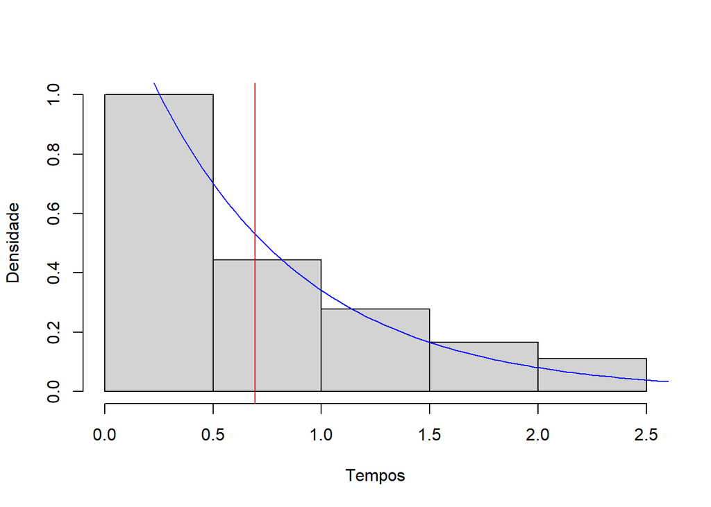

```r
hist(dados,freq=FALSE,xlab="Tempos",ylab="Densidade",main="")
curve(dexp(x,rate=1/mean(dados)),0,3,col="blue",add=TRUE)
abline(v=mean(dados),col="red")
```

# 4 Inferência para a proporção de uma população de Bernoulli: grandes amostras

## 4.1 Estimação da proporção

**Problema**. Uma amostra de 500 habitantes de uma cidade com idade igual ou superior a 16 anos foi selecionada para participar de uma pesquisa de opinião. Cada pessoa na amostra respondeu se concordava ou não com a solução proposta pela prefeitura da cidade para resolver um problema municipal que está prejudicando seriamente a população. As opções de resposta para a pergunta são: *sim* (se a pessoa é favorável a solução proposta) ou *não* (se a pessoa não é favorável a solução proposta). Das 500 pessoas ouvidas, 300 responderam *sim* e 200 responderam *não*. Com base nos dados, deseja-se testar se a proporção da população em questão (habitantes da cidade com idade igual ou superior a 16 anos) que é favorável a solução proposta pela prefeitura é igual a 1/2 ou é diferente de 1/2.

## 4.3 Exemplo de um teste de hipóteses para a proporção

**Problema**. Uma amostra de 500 habitantes de uma cidade com idade igual ou superior a 16 anos foi selecionada para participar de uma pesquisa de opinião. Cada pessoa na amostra respondeu se concordava ou não com a solução proposta pela prefeitura da cidade para resolver um problema municipal que está prejudicando seriamente a população. As opções de resposta para a pergunta são: *sim* (se a pessoa é favorável a solução proposta) ou *não* (se a pessoa não é favorável a solução proposta). Das 500 pessoas ouvidas, 300 responderam *sim* e 200 responderam *não*. Com base nos dados, deseja-se testar se a proporção da população em questão (habitantes da cidade com idade igual ou superior a 16 anos) que é favorável a solução proposta pela prefeitura é igual a 1/2 ou é diferente de 1/2.

```r
respostas <- c(rep("nao",200),rep("sim",300))
respostas <- factor(respostas,levels=c("nao","sim"))
df <- data.frame(Indivíduos=1:500,Resposta=respostas)
str(df)
```

```
## 'data.frame':    500 obs. of  2 variables:
##  $ Indivíduos: int  1 2 3 4 5 6 7 8 9 10 ...
##  $ Resposta  : Factor w/ 2 levels "nao","sim": 1 1 1 1 1 1 1 1 1 1 ...
```

```r
freq <- as.vector(table(df$Resposta))
prop <- as.vector(prop.table(table(df$Resposta)))
tabela <- data.frame(Classe=c("Não","Sim"),Frequencia=freq,Proporções=prop)
tabela
```

```
##   Classe Frequencia Proporções
## 1    Não        200        0.4
## 2    Sim        300        0.6
```

```r
#
# Teste para a proporção de uma população de Bernoulli
# sem correção de continuidade (grandes amostras)
#
out <- prop.test(x=300,n=500,p=0.5,alternative="two.sided",conf.level=0.95,correct=FALSE)
out
```

```
##
##  1-sample proportions test without continuity correction
##
## data:  300 out of 500, null probability 0.5
## X-squared = 20, df = 1, p-value = 7.744e-06
## alternative hypothesis: true p is not equal to 0.5
## 95 percent confidence interval:
##  0.5564541 0.6420210
## sample estimates:
##   p
## 0.6
```

```r
#
# Teste para a proporção de uma população de Bernoulli
# com correção de continuidade (grandes amostras)
#
out <- prop.test(x=300,n=500,p=0.5,alternative="two.sided",conf.level=0.95,correct=TRUE)
out
```

```
##
##  1-sample proportions test with continuity correction
##
## data:  300 out of 500, null probability 0.5
## X-squared = 19.602, df = 1, p-value = 9.537e-06
## alternative hypothesis: true p is not equal to 0.5
## 95 percent confidence interval:
##  0.5554442 0.6429956
## sample estimates:
##   p
## 0.6
```

```r
#
# Alternativamente, podemos utilizar também neste problema
# o teste qui-quadrado
#
out <- chisq.test(x=c(200,300),p=c(0.5,0.5),correct=FALSE)
out
```

```
##
##  Chi-squared test for given probabilities
##
## data:  c(200, 300)
## X-squared = 20, df = 1, p-value = 7.744e-06
```

```r
names(out)
```

```
## [1] "statistic" "parameter" "p.value"   "method"    "data.name" "observed"
## [7] "expected"  "residuals" "stdres"
```

```r
out$statistic
## X-squared
##        20
out$parameter
## df
##  1
pvalor <- 1-pchisq(out$statistic,df=out$parameter);pvalor
```

```
##    X-squared
## 7.744216e-06
```

## 4.4 Teste de hipóteses para a proporção: o teste binomial exato

**Problema**. Uma amostra de 500 habitantes de uma cidade com idade igual ou superior a 16 anos foi selecionada para participar de uma pesquisa de opinião. Cada pessoa na amostra respondeu se concordava ou não com a solução proposta pela prefeitura da cidade para resolver um problema municipal que está prejudicando seriamente a população. As opções de resposta para a pergunta são: *sim* (se a pessoa é favorável a solução proposta) ou *não* (se a pessoa não é favorável a solução proposta). Das 500 pessoas ouvidas, 300 responderam *sim* e 200 responderam *não*. Com base nos dados, deseja-se testar se a proporção da população em questão (habitantes da cidade com idade igual ou superior a 16 anos) que é favorável a solução proposta pela prefeitura é igual a 1/2 ou é diferente de 1/2.

```r
tabela
```

```
##   Classe Frequencia Proporções
## 1    Não        200        0.4
## 2    Sim        300        0.6
```

```r
#
# Teste binomial exato para a proporção de uma população de Bernoulli
#
out <- binom.test(x=300,n=500,p=0.5,alternative="two.sided",conf.level=0.95)
out
```

```
##
##  Exact binomial test
##
## data:  300 and 500
## number of successes = 300, number of trials = 500, p-value = 8.94e-06
## alternative hypothesis: true probability of success is not equal to 0.5
## 95 percent confidence interval:
##  0.5555718 0.6432386
## sample estimates:
## probability of success
##                    0.6
```

```r
names(out)
```

```
## [1] "statistic"   "parameter"   "p.value"     "conf.int"    "estimate"
## [6] "null.value"  "alternative" "method"      "data.name"
```

```r
out$p.value
```

```
## [1] 8.940067e-06
```

```r
as.vector(out$conf.int)
```

```
## [1] 0.5555718 0.6432386
```

```r
#
#
#
pvalor <- 2*(1-pbinom(299,size=500,prob=0.5));pvalor
```

```
## [1] 8.940067e-06
```

Rejeitamos a hipótese nula $H_{0}$ (veja que o p-valor é muito pequeno, $8.94\times 10^{-6}$). Portanto, existem evidências experimentais que a proporção da população em questão (habitantes da cidade com idade igual ou superior a 16 anos) que é favorável a solução proposta pela prefeitura é diferente de 1/2. A função `binom.test()` proporciona um intervalo de 95% confiança exato para $p$, que é dado por $\mbox{IC}(p;0.95)=(0.5555718,0.6432386)$. Note que, neste caso, o intervalo não contém $H_{0}$.

Os resultados obtidos com as funções `prop.test()` e `chisq.test()` estão em concordância com os resultados exatos obtidos com a função `binom.test()`.

| Teste | Decisão | P.valor | limite.inf.IC95 | limite.sup.IC95 |
| --- | --- | --- | --- | --- |
| Teste binomial exato | Rejeita H0 | 8.94e-06 | 0.5555718 | 0.6432386 |
| Teste-z sem correção (grandes amostras) | Rejeita H0 | 7.74e-06 | 0.5564541 | 0.6420210 |
| Teste-z com correção (grandes amostras) | Rejeita H0 | 9.54e-06 | 0.5554442 | 0.6429956 |